# Assignment 1

Jeff Gould

1/31/2021

# 1

Show that the conditional distribution is a valid pmf/pdf for both continuous and discrete random variables:

Need to show: probabilty is $\geq 0$ and total probability sums to 1

$P(Y | X = x_i) = \frac{P(X \cap Y)}{P(X)}$

Discrete:

$\sum_y f(y | x) = \frac{\sum_y f(y,x)}{f_x(x)} = \frac{f_x(x)}{f_x(x)} = 1$

Continuous:

$\int_y f(y |x) dy = \frac{\int_y f(x,y) dy}{f_x(x)} = \frac{f_x(x)}{f_x(x)} = 1$

And, since $f(x,y) \geq 0$, as it’s a valid probabilty distribution, and $f_x(x) > 0$, then $f(y|x) \geq 0$

Therefore, the conditional distribution is a valid pmf/pdf

# 2

## a)

$\theta \sim Beta(\alpha, \beta)$

$P(\theta) = \frac{\Gamma(\alpha + \beta)}{\Gamma(\alpha)\Gamma(\beta)} \theta^{\alpha-1} (1 - \theta)^{\beta - 1}$

$E[\theta] = \int_0^1 \theta \frac{\Gamma(\alpha + \beta)}{\Gamma(\alpha)\Gamma(\beta)} \theta^{\alpha-1} (1 - \theta)^{\beta - 1} d\theta = \int_0^1 \frac{\Gamma(\alpha + \beta)}{\Gamma(\alpha)\Gamma(\beta)} \theta^{\alpha-1+1} (1 - \theta)^{\beta - 1} d\theta$

$\theta^{\alpha-1+1} (1 - \theta)^{\beta - 1}$ is the kernel for a $Beta(\alpha + 1, \beta)$ distribution

$\frac{\Gamma(\alpha + \beta)}{\Gamma(\alpha)\Gamma(\beta)} = \frac{\alpha\Gamma(\alpha + \beta)}{\Gamma(\alpha+1)\Gamma(\beta)}\frac{\alpha\Gamma(\alpha + \beta + 1)}{(\alpha + \beta)\Gamma(\alpha+1)\Gamma(\beta)}$

Substitute:

$\int_0^1 \frac{\Gamma(\alpha + \beta)}{\Gamma(\alpha)\Gamma(\beta)} \theta^{\alpha-1+1} (1 - \theta)^{\beta - 1} d\theta = \int_0^1 \frac{\alpha\Gamma(\alpha + \beta + 1)}{(\alpha + \beta)\Gamma(\alpha+1)\Gamma(\beta)} \theta^{\alpha - 1 + 1}(1-\theta)^{\beta - 1}d\theta = \frac{\alpha}{\alpha + \beta}\int_0^1 \frac{\Gamma(\alpha + \beta + 1)}{\Gamma(\alpha+1)\Gamma(\beta)} \theta^{\alpha - 1 + 1}(1-\theta)^{\beta - 1}d\theta = \frac{\alpha}{\alpha + \beta}$

## b)

$\mu \sim Pois(\lambda)$

$P(\mu) = \frac{\lambda^{\mu} e^{-\lambda}}{\mu!}$

$E[\mu] - \sum_{\mu = 0}^{\infty}\frac{\mu \lambda^{\mu}e^{-\lambda}}{\mu!} = \lambda \sum_{\mu = 1}^{\infty} \frac{ \lambda^{\mu-1}e^{-\lambda}}{(\mu-1)!}$

$\frac{ \lambda^{\mu-1}e^{-\lambda}}{(\mu-1)!}$ is the kernel for $(\mu - 1) \sim Pois(\lambda)$, so

$\sum_{\mu = 1}^{\infty} \frac{ \lambda^{\mu-1}e^{-\lambda}}{(\mu-1)!} = \sum_{\mu - 1 =0}^{\infty} \frac{ \lambda^{\mu-1}e^{-\lambda}}{(\mu-1)!} = 1$

And

$\lambda \sum_{\mu = 1}^{\infty} \frac{ \lambda^{\mu-1}e^{-\lambda}}{(\mu-1)!}$

Therefore, $E[\mu] = \lambda$

## c)

$\nu \sim Binom(n,p)$

$P(\nu) = \sum_{\nu = 0}^n \binom{n}{\nu} p^{\nu}(1-p)^{n - \nu}$

$E[\nu] = \sum_{\nu = 0}^n \nu \binom{n}{\nu} p^{\nu}(1-p)^{n - \nu}= \sum_{\nu = 1}^n \nu \binom{n}{\nu} p^{\nu}(1-p)^{n - \nu}$

$\nu \binom{n}{\nu} = n \binom{n-1}{\nu - 1}$ Let $\eta = \nu - 1$ and $m = n-1$

$\sum_{\nu = 1}^n \nu \binom{n}{\nu} p^{\nu}(1-p)^{n - \nu} =\sum_{\nu = 1}^n n \binom{n-1}{\nu - 1} p^{\nu}(1-p)^{n - \nu}= n\sum_{\nu = 1}^n \binom{n-1}{\nu - 1} p \cdot p^{\nu-1}(1-p)^{(n-1) - (\nu-1)} =np \sum_{\eta = 0}^m \binom{m}{\eta} p^{\eta}(1-p)^{n - \eta}$

and the summation is the kernel for $\eta \sim Binom(m,p)$, so it sums to 1

Therefore $E[\nu] = np$

## d)

$\gamma \sim Exp(\beta)$

$P(\gamma) = \beta e^{-\beta \gamma}$

$E[\gamma] = \int_0^{\infty} \gamma \beta e^{-\beta\gamma} d\gamma$

$\gamma^{2-1}e^{-\beta \gamma}$ forms the kernel for $Gamma(\alpha = 2, \beta)$

$\int_0^{\infty} \gamma \beta e^{-\beta\gamma} d\gamma = \int_0^{\infty} \frac{\beta}{\beta} \gamma^{2-1} \beta e^{-\beta\gamma} d\gamma = \frac{1}{\beta} \int_0^{\infty} \gamma^{2-1} \beta^2 e^{-\beta \gamma} d\gamma$

$\int_0^{\infty} \gamma^{2-1} \beta^2 e^{-\beta \gamma} d\gamma$ is the pdf for $Gamma(\alpha = 2, \beta)$, so the integral computes to 1.

# 3

$X | N,P \sim Binom(N,P)$

$N \sim Pois(\Lambda)$

$\Lambda \sim Gamma(\alpha, \beta)$

$P \sim Beta(\gamma, \zeta)$

$E[X] = E[NP] = E[N]E[P]$

$E[N] = E[\Lambda] = \frac{\alpha}{\beta}$

$E[P] = \frac{\gamma}{\gamma + \zeta}$

$E[X] = \frac{\alpha}{\beta}\frac{\gamma}{\gamma + \zeta}$

# 4

$\beta \sim Gamma(1800, 10)$

$\epsilon \sim \mathcal{N}(e, \tau_e^2$

$\delta \sim \mathcal{N}(d, \tau_d^2)$

$Y_i | \beta, \epsilon, \delta, T_i \sim \mathcal{N}\left[ \beta + \epsilon \cdot 1(T_i = 0) + \delta \cdot 1(T_i = 1), \sigma^2\right]$

$E[Y_i] = E[\mathcal{N}\left[ \beta + \epsilon \cdot 1(T_i = 0) + \delta \cdot 1(T_i = 1), \sigma^2\right]] = E[\beta + \epsilon \cdot 1(T_i = 0) + \delta \cdot 1(T_i = 1)] = E[\beta] + E[\epsilon]E[T_i=0] + E[\delta]E[T_i=1]=$

$\frac{1800}{10} + 0.5(\epsilon) + 0.5(\delta) = 180 + 0.5(\epsilon + \delta)$

# Computation

## 1

### a) $\theta \sim Exp(27)$

$P(\Theta \leq \theta) = P(U \leq u)$

$F_{\theta}(\theta) = F_U(u)$

$1 - exp(-\theta / 27) = u$

$\theta = -27 \log (1 - u)$

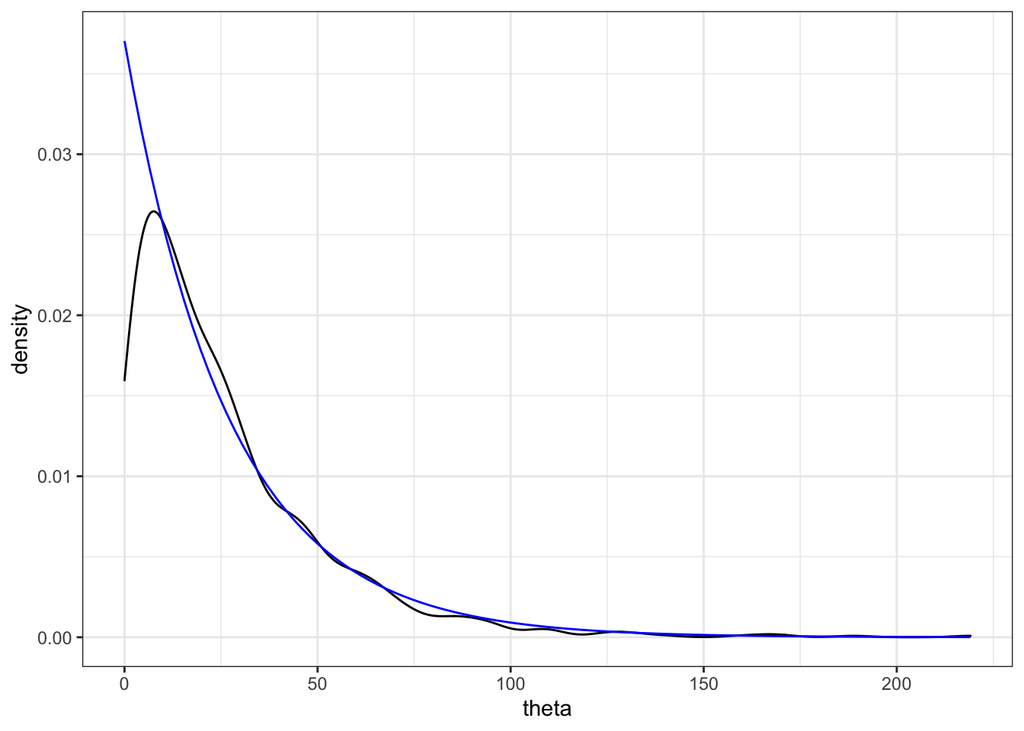

```r
set.seed(108)
u <- runif(1000)
theta <- -27 * log(1 - u)

ggplot(data.frame(theta = theta)) +
  geom_density(aes(x = theta)) +
  stat_function(data = data.frame(x. = c(0, 200)), aes(x = x.), fun = dexp, args = list(rate = 1/27), geom = "line",
                color = "blue") +
  theme_bw()
```

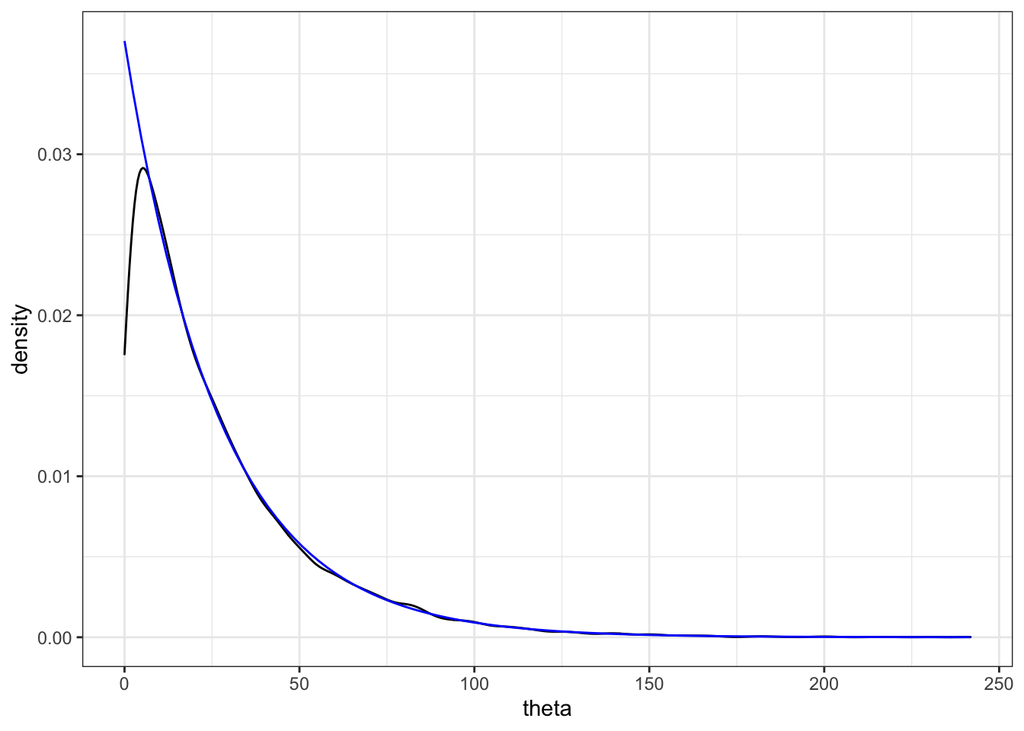

```r
set.seed(108)
u <- runif(10000)
theta <- -27 * log(1 - u)

ggplot(data.frame(theta = theta)) +
  geom_density(aes(x = theta)) +
  stat_function(data = data.frame(x. = c(0, 200)), aes(x = x.), fun = dexp, args = list(rate = 1/27), geom = "line",
                color = "blue") +
  theme_bw()
```

### b) $\theta \sim Cauchy(-7,2)$

$F_{\theta}(\theta) = F_U(u)$

$\frac{1}{\pi} \arctan(\frac{\theta - -7}{2}) + \frac{1}{2} = u$

$\arctan(\frac{\theta + 7}{2}) = \pi u - \frac{\pi}{2}$

$\frac{\theta + 7}{2} = \tan(\pi u - \frac{\pi}{2})$

$\theta = 2 \tan(\pi u - \frac{\pi}{2}) - 7$

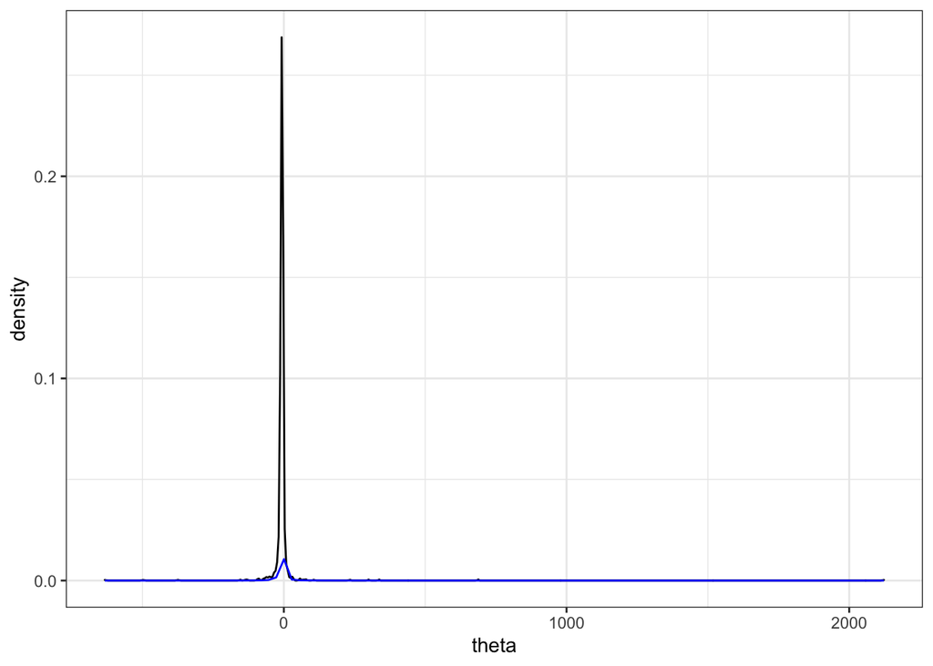

```r
set.seed(108)
u <- runif(1000)
theta <- 2 * tan(pi * u - pi / 2) - 7

ggplot(data.frame(theta = theta)) +
  geom_density(aes(x = theta)) +
  stat_function(data = data.frame(x. = c(-500, 500)), aes(x = x.), fun = dcauchy, args = list(location = -7, scale = 2), geom = "line",
                color = "blue") +
  theme_bw()
```

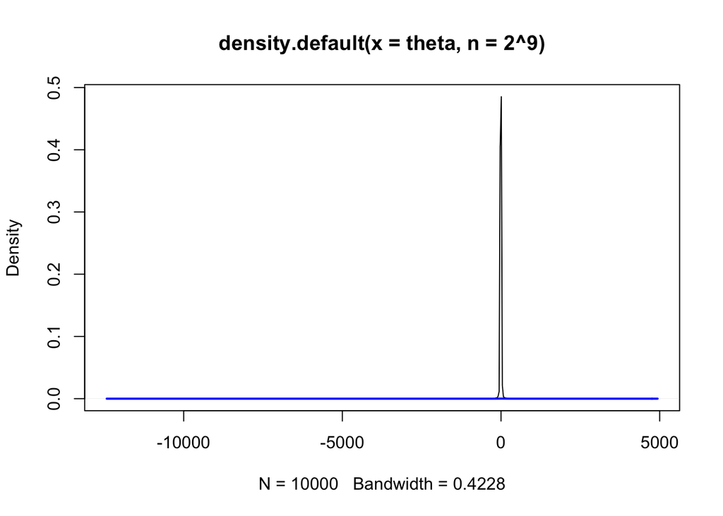

```r
set.seed(108)
u <- runif(10000)
theta <- 2 * tan(pi * (u - 0.5)) - 7

plot(density(theta, n = 2^9))
curve(dcauchy(x, location = -7, scale = 2), add = TRUE, col = 'blue', lwd = 2)
```

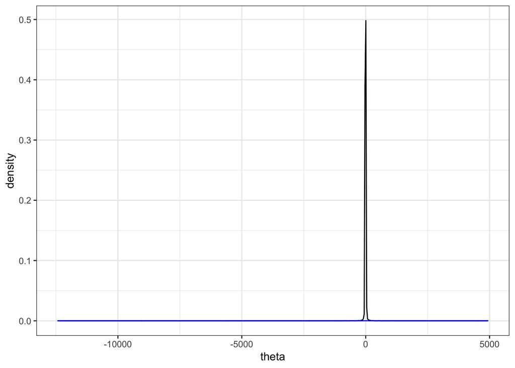

```r
ggplot(data.frame(theta = theta)) +
  geom_density(aes(x = theta), n = 2^9) +
  stat_function(data = data.frame(x. = c(-500, 500)), aes(x = x.), fun = dcauchy, args = list(location = -7, scale = 2), geom = "line",
                color = "blue") +
  theme_bw()
```

### c) $\theta \sim Gumbel(3,6)$

$F_{\theta}(\theta) = e^{-e^{-(\theta - 3)/6}}$

$e^{-e^{-(\theta - 3)/6}} = u$

$e^{-(\theta - 3)/6} = -\log(u)$

$-(\theta - 3)/6 = \log(-\log(u))$

$\theta = -6\log(-\log(u)) + 3$

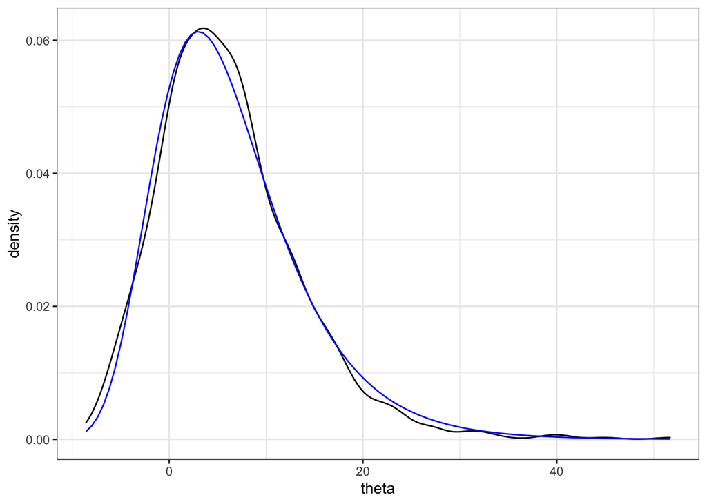

```r
set.seed(108)
u <- runif(1000)
theta <- -6 * log(-log(u)) + 3

ggplot(data.frame(theta = theta)) +
  geom_density(aes(x = theta)) +
  stat_function(data = data.frame(x. = c(0, 20)), aes(x = x.),
                fun = extraDistr::dgumbel, args = list(mu = 3, sigma = 6), geom = "line",
                color = "blue") +
  theme_bw()
```

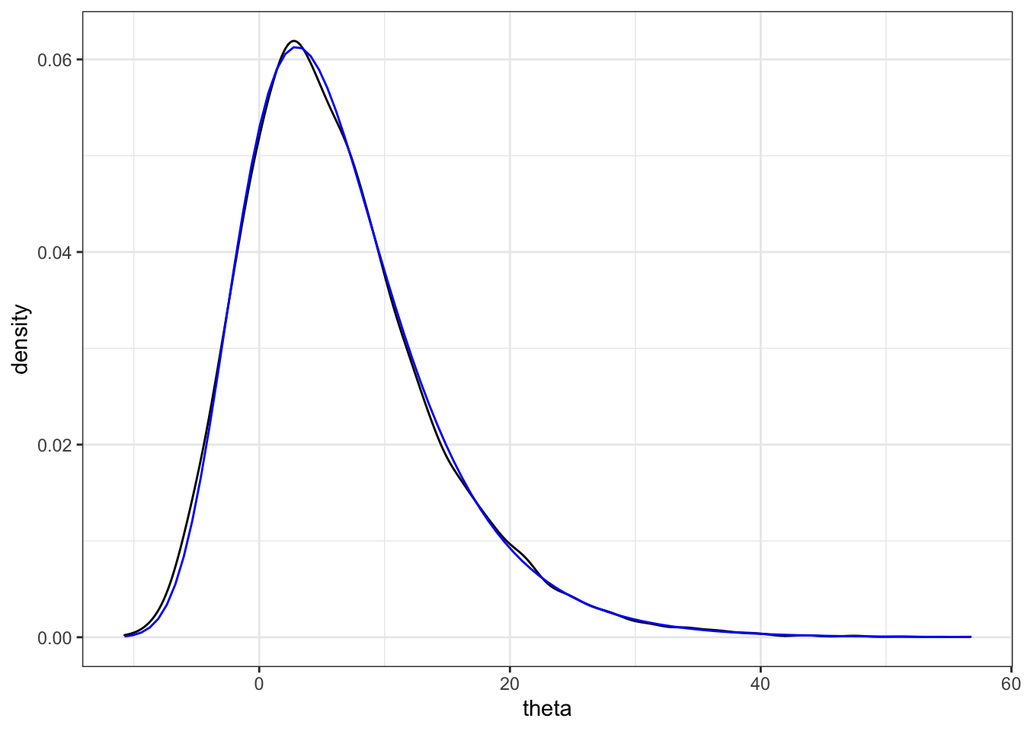

```r
set.seed(108)
u <- runif(10000)
theta <- -6 * log(-log(u)) + 3

ggplot(data.frame(theta = theta)) +
  geom_density(aes(x = theta)) +
  stat_function(data = data.frame(x. = c(0, 20)), aes(x = x.),
                fun = extraDistr::dgumbel, args = list(mu = 3, sigma = 6), geom = "line",
                color = "blue") +
  theme_bw()
```